# 长周期估值因子

量化投资部

## 加载数据

```r
#  -------single factor test step by step  -----
fls <- buildFactorLists(
  buildFactorList(factorFun = "gf.ca_ratio",
                  factorDir = -1,
                  factorPar=list(fintype='PE',N = 3),
                  factorName = "cape3"),
    buildFactorList(factorFun = "gf.ca_ratio",
                  factorDir = -1,
                  factorPar=list(fintype='PE',N = 5),
                  factorName = "cape5"),
  buildFactorList(factorFun = "gf.ca_ratio",
                  factorDir = -1,
                  factorPar=list(fintype='PB',N = 3),
                  factorName = "capb"),
  buildFactorList(factorFun = "gf.ca_ratio",
                  factorDir = -1,
                  factorPar=list(fintype='PB',N = 3,inflaAdj = TRUE),
                  factorName = "capb_adj"),
  buildFactorList(factorFun = "gf.ca_ratio",
                  factorDir = -1,
                  factorPar=list(fintype='PCF',N = 3),
                  factorName = "capcf"),
    buildFactorList(factorFun = "gf.PB_mrq",
                  factorDir = -1,
                  factorPar=list(),
                  factorName = "pb_mrq"),
    buildFactorList(factorFun = "gf.PE_ttm",
                  factorDir = -1,
                  factorPar=list(),
                  factorName = "pe_ttm"),
    buildFactorList(factorFun = "gf.PCF_ttm",
                  factorDir = -1,
                  factorPar=list(),
                  factorName = "pcf_ttm"))


# time and univ setting
begT <- as.Date("2005-01-04")
endT <- as.Date("2017-10-31")
holdingEndT <- as.Date("2017-11-30")
rebFreq <- "quarter"
shiftby <- 0
univ <- "EI000985"

# getTSR
rebdate <- getRebDates(begT,endT,rebFreq,shiftby)
ts <- getTS(rebdate,indexID = univ,rm=c("priceLimit","suspend"))
tsr <- getTSR(ts,date_end_pad = holdingEndT)


# raw factor descrptive statistics
tsfr_raw <- getMultiFactor(tsr,FactorList = fls)
tsfrs_raw <- mTSF2TSFs(tsfr_raw)


# table.Fct_descr(tsfr_raw,9)
# sectorAttrs <- list(ind=defaultSectorAttr("ind"),
#                     fct=defaultSectorAttr("fct"),
#                     ind_fct=defaultSectorAttr("ind_fct"))
# chart.Fct_anova(tsfr_raw,sectorAttrs)

# factor refine research
refinePars <- list(scale = refinePar_default("scale",NULL),
                   scale_ind = refinePar_default("scale",defaultSectorAttr("ind")),
                   scale_indfct= refinePar_default("scale",defaultSectorAttr("ind_fct")),
                   reg_indfct = refinePar_default("reg",defaultSectorAttr("ind")))
tablestats <- data.frame()
mtsfrrefine <- data.frame()
```

## PE_ttm

```r
fname_ <- "pe_ttm"
tsfr <- tsfrs_raw[[fname_]]
mtsfr <- factor_refine_MF(tsfr,refinePars)
```

```
## Function getTSF: getting the factorscore ....
## Function getTSF: getting the factorscore ....
```

```r
mtsfrrefine <- rbind(mtsfrrefine,data.frame(mtsfr,fname=fname_))
```

不同refine方式下因子得分分布直方图

```
## The guessed factorNames are: scale,scale_ind,scale_indfct,reg_indfct.
```

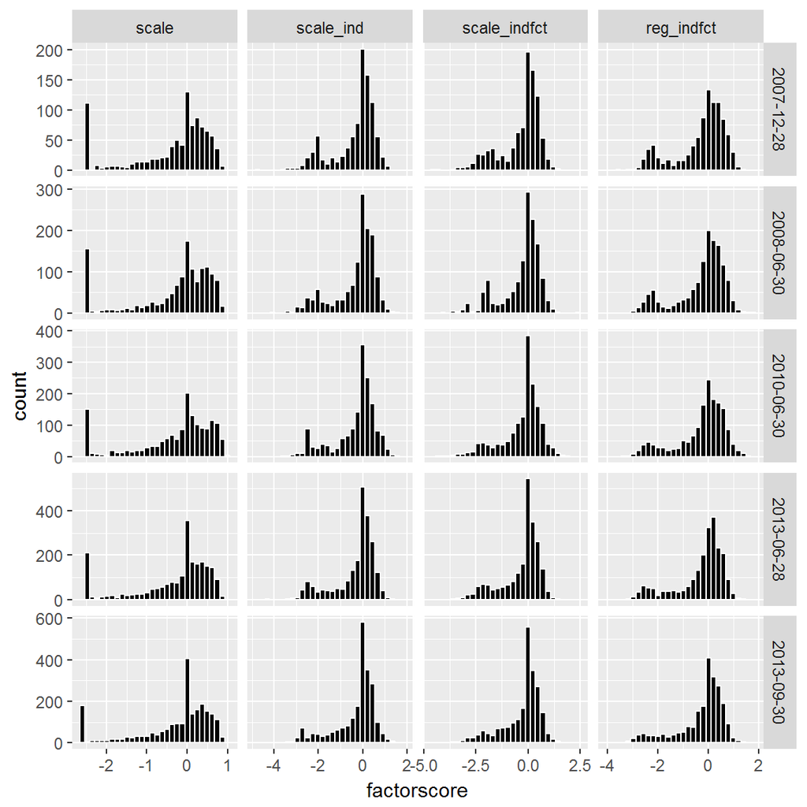

```r
MF.chart.Fct_hist(mtsfr,5)
```

不同refine方式下因子IC图

```
## The guessed factorNames are: scale,scale_ind,scale_indfct,reg_indfct.
```

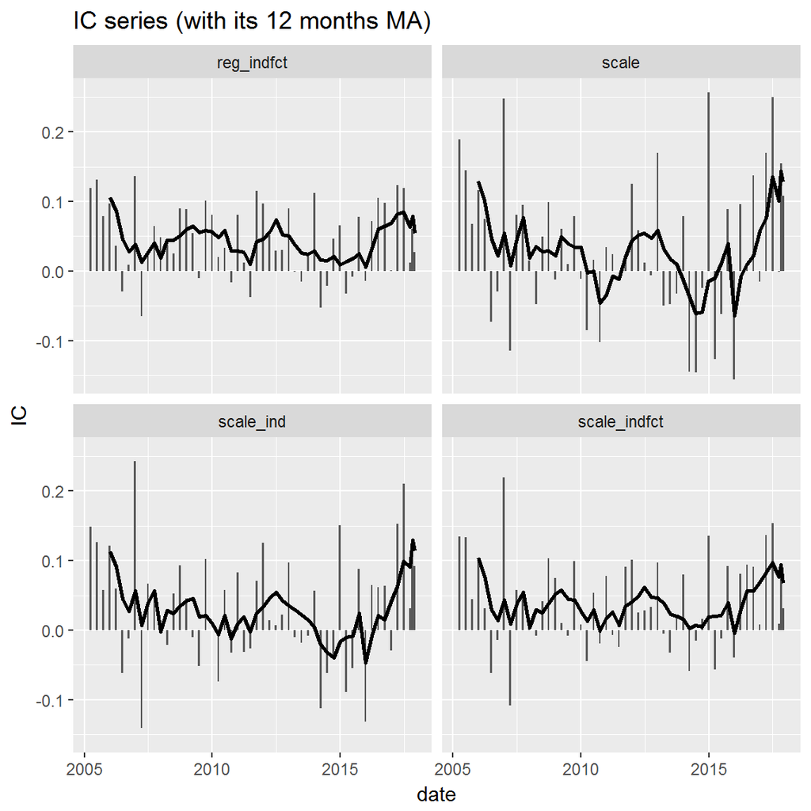

```r
MF.chart.IC(mTSFR = mtsfr,facet_by = 'fname')
```

不同refine方式下因子分组多空收益图

```
## The guessed factorNames are: scale,scale_ind,scale_indfct,reg_indfct.
```

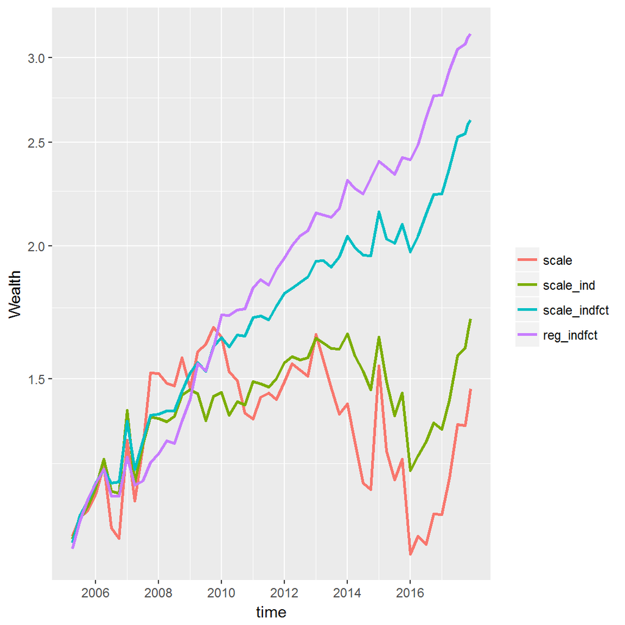

```r
MF.chart.Ngroup.spread(mTSFR = mtsfr, N = 5)
```

不同refine方式下因子分组多空相对收益图

```
## The guessed factorNames are: scale,scale_ind,scale_indfct,reg_indfct.
```

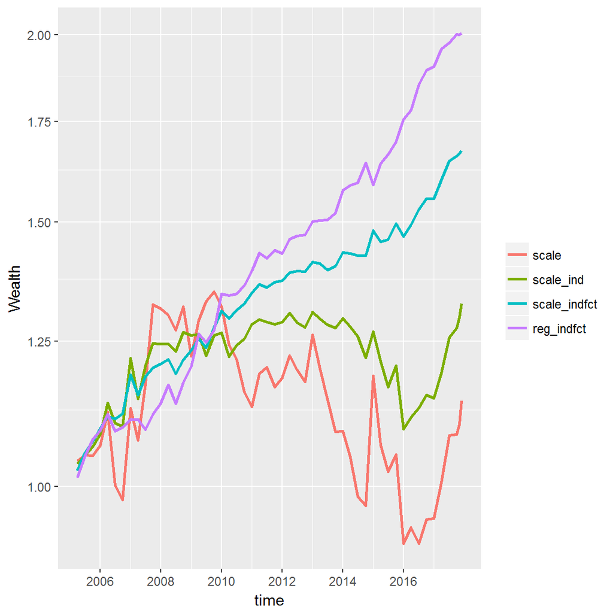

```r
MF.chart.Ngroup.spread(mTSFR = mtsfr, N = 5,rtn_type = "long-univ")
```

不同refine方式下因子IC和分组收益统计表

```r
table_ <- MC.table.ICandNgroup(mTSF2TSFs(mtsfr), N = 5)
```

```
## The guessed factorNames are: scale,scale_ind,scale_indfct,reg_indfct.
```

```r
kable(table_,digits = 2)
```

|  | IC_mean | IC_std | IC_IR | IC_t | IC_p | IC_hitRatio | IC_annu | Annualized Return | Annualized StdDev | Annualized Sharpe(Rf=0%) | HitRatio | Worst Drawdown | Annualized Turnover | Annualized Return (fee cut) | Beta | Size |
| --- | --- | --- | --- | --- | --- | --- | --- | --- | --- | --- | --- | --- | --- | --- | --- | --- |
| scale | 0.04 | 0.10 | 0.35 | 2.52 | 0.01 | 0.60 | 0.07 | 0.03 | 0.18 | 0.17 | 0.49 | 0.39 | 1.14 | 0.03 | -0.11 | 318.67 |
| scale_ind | 0.03 | 0.08 | 0.40 | 2.89 | 0.01 | 0.62 | 0.07 | 0.04 | 0.12 | 0.36 | 0.58 | 0.26 | 1.31 | 0.04 | -0.13 | 150.47 |
| scale_indfct | 0.04 | 0.07 | 0.62 | 4.53 | 0.00 | 0.70 | 0.08 | 0.08 | 0.08 | 0.99 | 0.75 | 0.10 | 1.52 | 0.08 | -0.08 | 99.35 |
| reg_indfct | 0.05 | 0.05 | 0.87 | 6.37 | 0.00 | 0.77 | 0.09 | 0.09 | 0.06 | 1.50 | 0.74 | 0.06 | 1.38 | 0.09 | -0.04 | -115.75 |

```r
table_ <- data.frame(factorName=fname_,refinePar=rownames(table_),table_,row.names = NULL,stringsAsFactors = FALSE)
tablestats <- rbind(tablestats,table_)
```

## PE三年期

```r
fname_ <- "cape3"
tsfr <- tsfrs_raw[[fname_]]
mtsfr <- factor_refine_MF(tsfr,refinePars)
```

```
## Function getTSF: getting the factorscore ....
## Function getTSF: getting the factorscore ....
```

```r
mtsfrrefine <- rbind(mtsfrrefine,data.frame(mtsfr,fname=fname_))
```

不同refine方式下因子得分分布直方图

```
## The guessed factorNames are: scale,scale_ind,scale_indfct,reg_indfct.
```

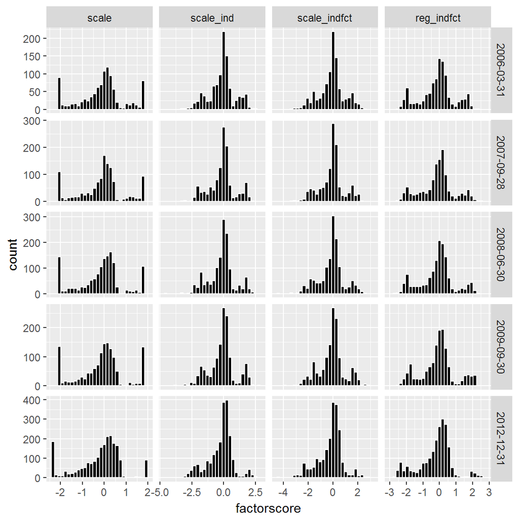

```r
MF.chart.Fct_hist(mtsfr,5)
```

不同refine方式下因子IC图

```
## The guessed factorNames are: scale,scale_ind,scale_indfct,reg_indfct.
```

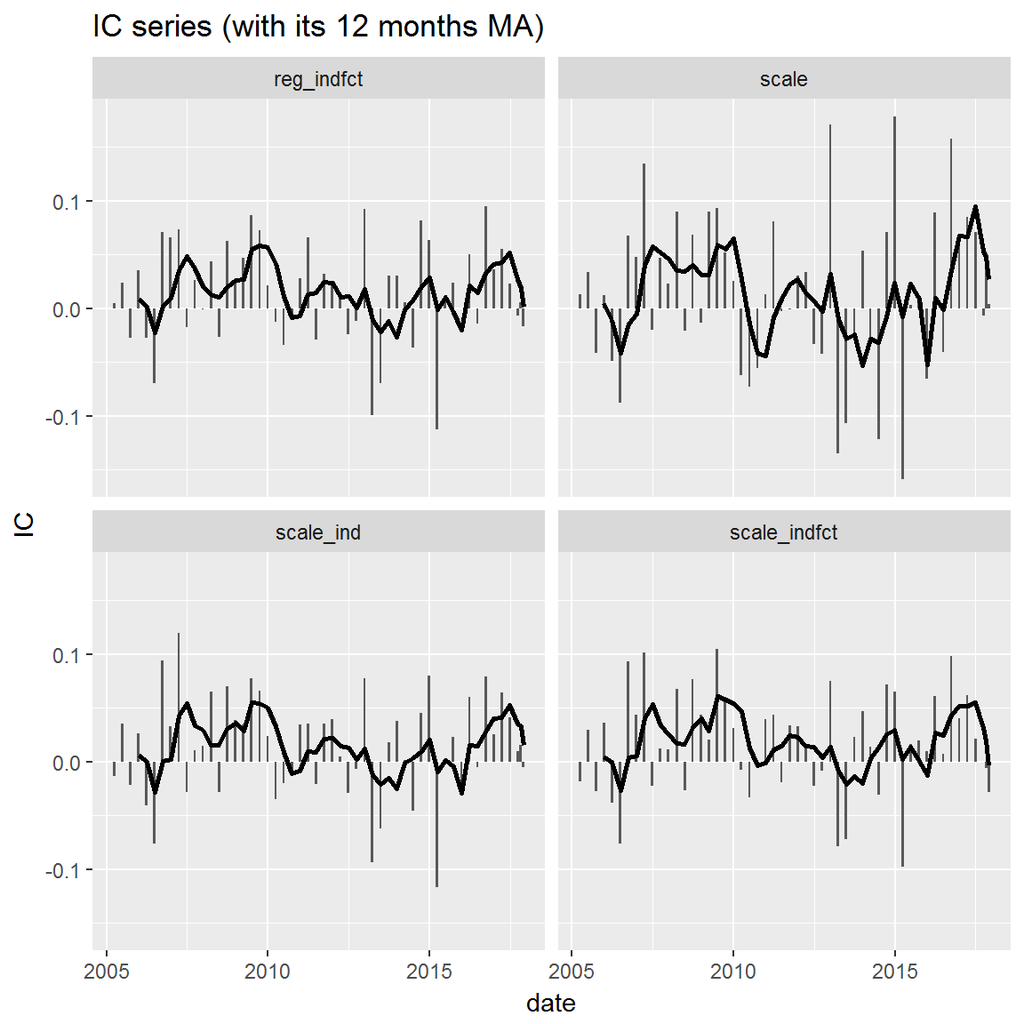

```r
MF.chart.IC(mTSFR = mtsfr,facet_by = 'fname')
```

不同refine方式下因子分组多空收益图

```
## The guessed factorNames are: scale,scale_ind,scale_indfct,reg_indfct.
```

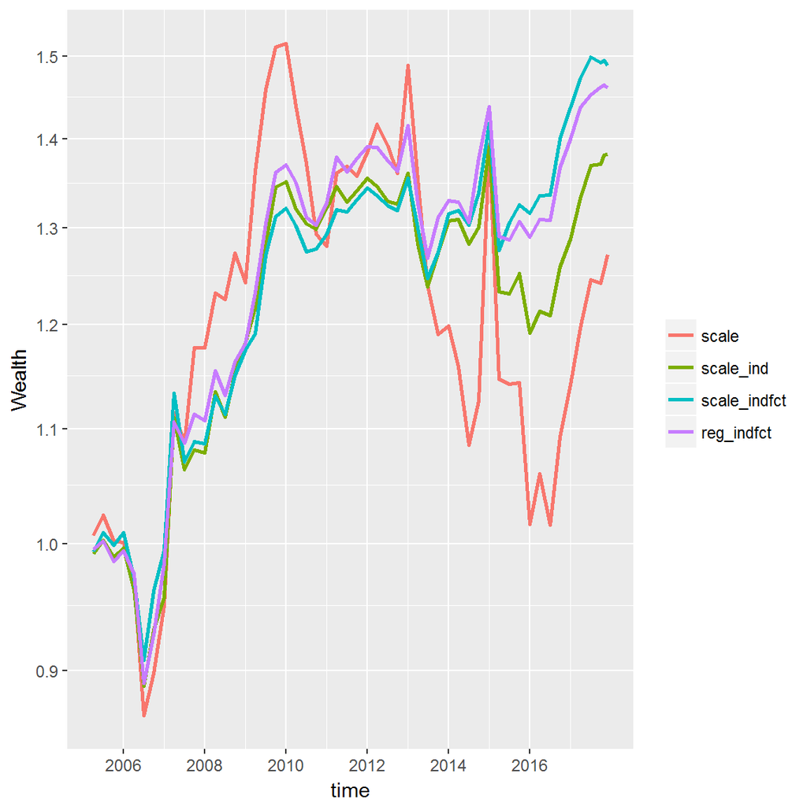

```r
MF.chart.Ngroup.spread(mTSFR = mtsfr, N = 5)
```

不同refine方式下因子分组多空相对收益图

```
## The guessed factorNames are: scale,scale_ind,scale_indfct,reg_indfct.
```

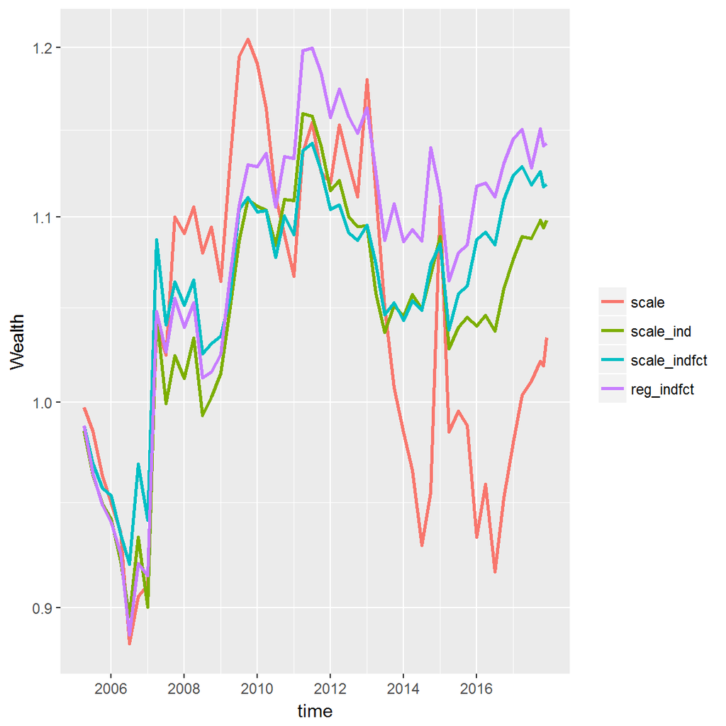

```r
MF.chart.Ngroup.spread(mTSFR = mtsfr, N = 5,rtn_type = "long-univ")
```

不同refine方式下因子IC和分组收益统计表

```r
table_ <- MC.table.ICandNgroup(mTSF2TSFs(mtsfr), N = 5)
```

```
## The guessed factorNames are: scale,scale_ind,scale_indfct,reg_indfct.
```

```r
kable(table_,digits = 2)
```

|  | IC_mean | IC_std | IC_IR | IC_t | IC_p | IC_hitRatio | IC_annu | Annualized Return | Annualized StdDev | Annualized Sharpe(Rf=0%) | HitRatio | Worst Drawdown | Annualized Turnover | Annualized Return (fee cut) | Beta | Size |
| --- | --- | --- | --- | --- | --- | --- | --- | --- | --- | --- | --- | --- | --- | --- | --- | --- |
| scale | 0.01 | 0.07 | 0.20 | 1.42 | 0.16 | 0.58 | 0.03 | 0.02 | 0.14 | 0.14 | 0.53 | 0.33 | 0.96 | 0.02 | 0.00 | 218.14 |
| scale_ind | 0.01 | 0.05 | 0.30 | 2.19 | 0.03 | 0.62 | 0.03 | 0.03 | 0.08 | 0.32 | 0.60 | 0.14 | 1.08 | 0.03 | 0.00 | 117.19 |
| scale_indfct | 0.02 | 0.05 | 0.37 | 2.68 | 0.01 | 0.66 | 0.03 | 0.03 | 0.07 | 0.43 | 0.62 | 0.10 | 1.18 | 0.03 | 0.01 | 97.71 |
| reg_indfct | 0.01 | 0.05 | 0.32 | 2.33 | 0.02 | 0.64 | 0.03 | 0.03 | 0.07 | 0.40 | 0.57 | 0.11 | 1.08 | 0.03 | 0.02 | 27.51 |

```r
table_ <- data.frame(factorName=fname_,refinePar=rownames(table_),table_,row.names = NULL,stringsAsFactors = FALSE)
tablestats <- rbind(tablestats,table_)
```

## PE五年期

```r
fname_ <- "cape5"
tsfr <- tsfrs_raw[[fname_]]
mtsfr <- factor_refine_MF(tsfr,refinePars)
```

```
## Function getTSF: getting the factorscore ....
## Function getTSF: getting the factorscore ....
```

```r
mtsfrrefine <- rbind(mtsfrrefine,data.frame(mtsfr,fname=fname_))
```

不同refine方式下因子得分分布直方图

```
## The guessed factorNames are: scale,scale_ind,scale_indfct,reg_indfct.
```

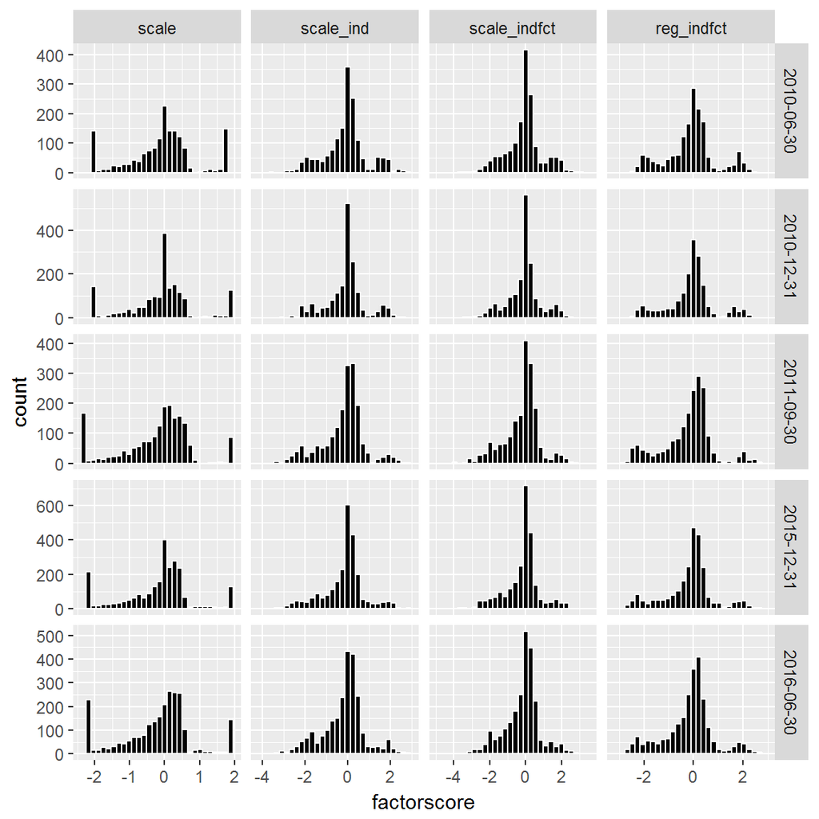

```r
MF.chart.Fct_hist(mtsfr,5)
```

不同refine方式下因子IC图

```
## The guessed factorNames are: scale,scale_ind,scale_indfct,reg_indfct.
```

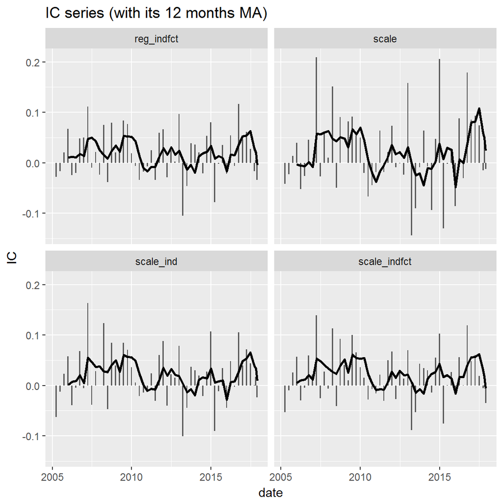

```r
MF.chart.IC(mTSFR = mtsfr,facet_by = 'fname')
```

不同refine方式下因子分组多空收益图

```
## The guessed factorNames are: scale,scale_ind,scale_indfct,reg_indfct.
```

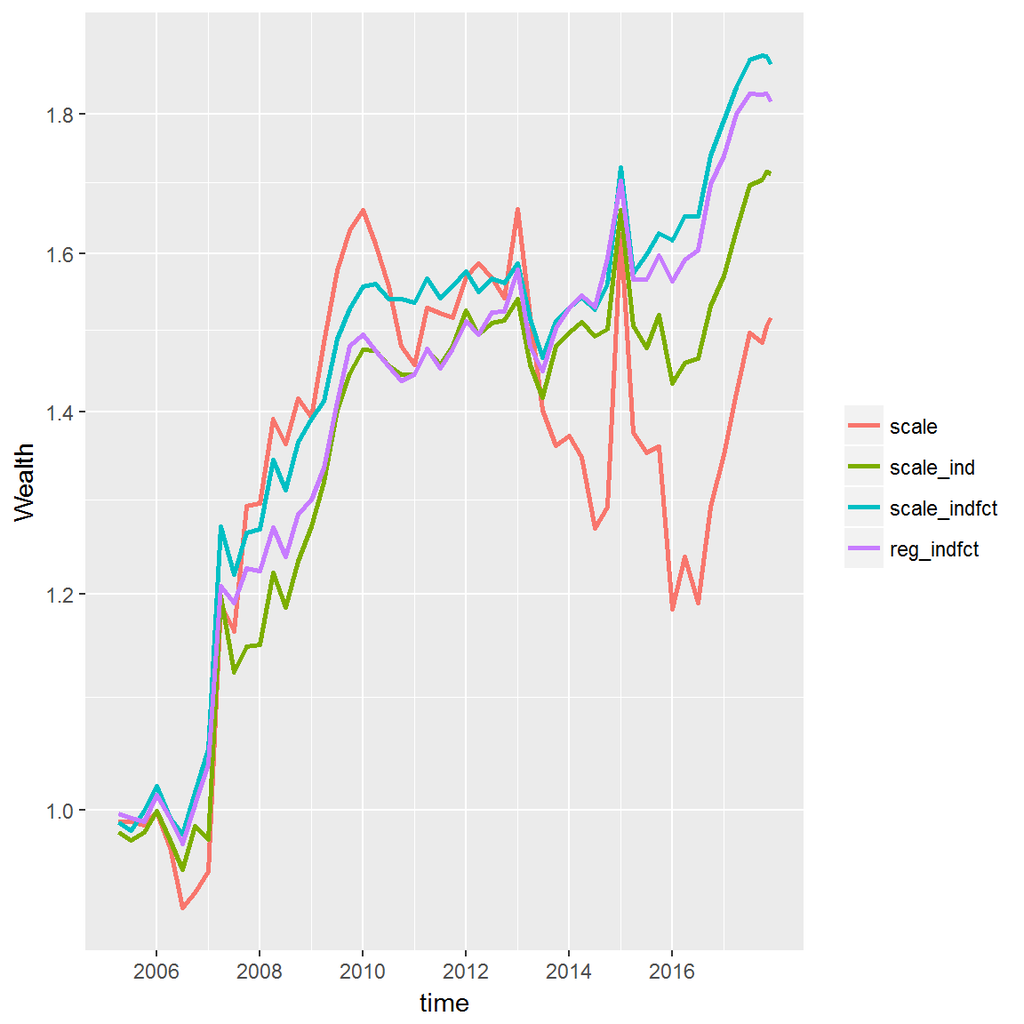

```r
MF.chart.Ngroup.spread(mTSFR = mtsfr, N = 5)
```

不同refine方式下因子分组多空相对收益图

```
## The guessed factorNames are: scale,scale_ind,scale_indfct,reg_indfct.
```

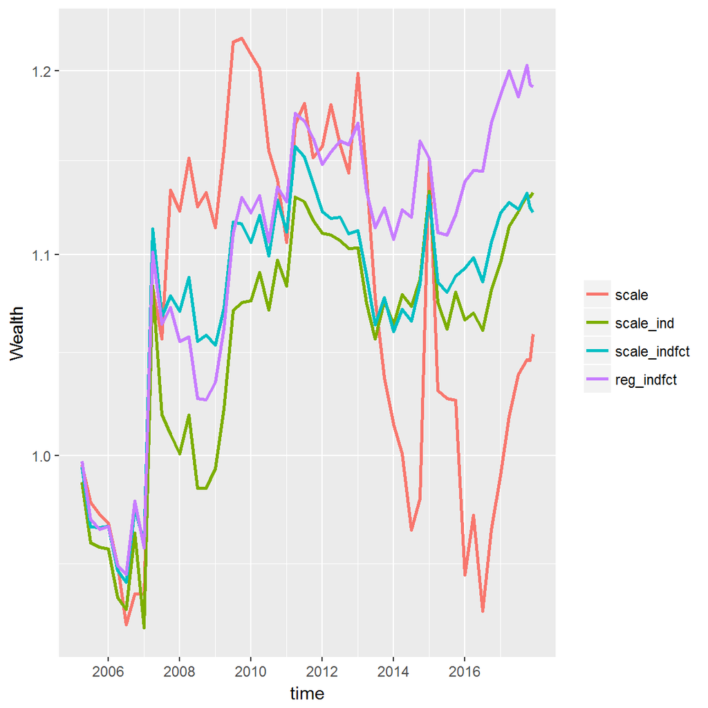

```r
MF.chart.Ngroup.spread(mTSFR = mtsfr, N = 5,rtn_type = "long-univ")
```

不同refine方式下因子IC和分组收益统计表

```r
table_ <- MC.table.ICandNgroup(mTSF2TSFs(mtsfr), N = 5)
```

```
## The guessed factorNames are: scale,scale_ind,scale_indfct,reg_indfct.
```

```r
kable(table_,digits = 2)
```

|  | IC_mean | IC_std | IC_IR | IC_t | IC_p | IC_hitRatio | IC_annu | Annualized Return | Annualized StdDev | Annualized Sharpe(Rf=0%) | HitRatio | Worst Drawdown | Annualized Turnover | Annualized Return (fee cut) | Beta | Size |
| --- | --- | --- | --- | --- | --- | --- | --- | --- | --- | --- | --- | --- | --- | --- | --- | --- |
| scale | 0.02 | 0.08 | 0.27 | 1.93 | 0.06 | 0.51 | 0.04 | 0.03 | 0.14 | 0.23 | 0.53 | 0.29 | 0.92 | 0.03 | 0.03 | 207.25 |
| scale_ind | 0.02 | 0.05 | 0.36 | 2.62 | 0.01 | 0.60 | 0.04 | 0.04 | 0.09 | 0.46 | 0.62 | 0.14 | 1.03 | 0.04 | 0.03 | 125.50 |
| scale_indfct | 0.02 | 0.05 | 0.41 | 3.00 | 0.00 | 0.62 | 0.04 | 0.05 | 0.08 | 0.62 | 0.66 | 0.09 | 1.12 | 0.05 | 0.04 | 105.42 |
| reg_indfct | 0.02 | 0.05 | 0.37 | 2.67 | 0.01 | 0.58 | 0.04 | 0.05 | 0.07 | 0.67 | 0.62 | 0.08 | 1.02 | 0.05 | 0.03 | 60.31 |

```r
table_ <- data.frame(factorName=fname_,refinePar=rownames(table_),table_,row.names = NULL,stringsAsFactors = FALSE)
tablestats <- rbind(tablestats,table_)
```

## PB_mrq

```r
fname_ <- "pb_mrq"
tsfr <- tsfrs_raw[[fname_]]
mtsfr <- factor_refine_MF(tsfr,refinePars)
```

```
## Function getTSF: getting the factorscore ....
## Function getTSF: getting the factorscore ....
```

```r
mtsfrrefine <- rbind(mtsfrrefine,data.frame(mtsfr,fname=fname_))
```

不同refine方式下因子得分分布直方图

```
## The guessed factorNames are: scale,scale_ind,scale_indfct,reg_indfct.
```

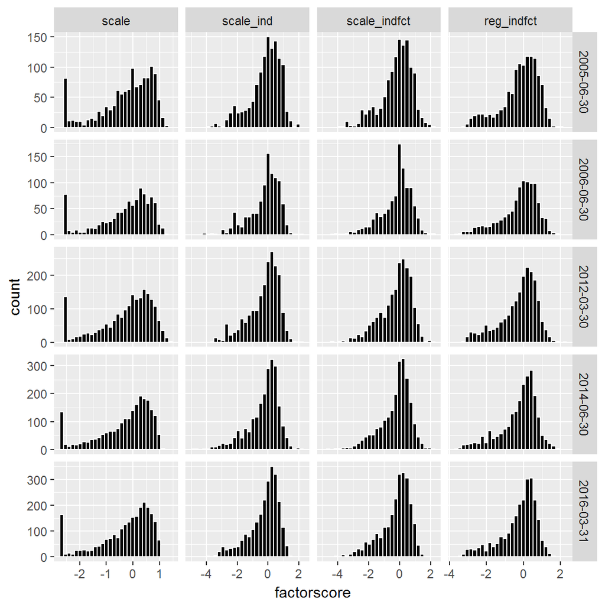

```r
MF.chart.Fct_hist(mtsfr,5)
```

不同refine方式下因子IC图

```
## The guessed factorNames are: scale,scale_ind,scale_indfct,reg_indfct.
```

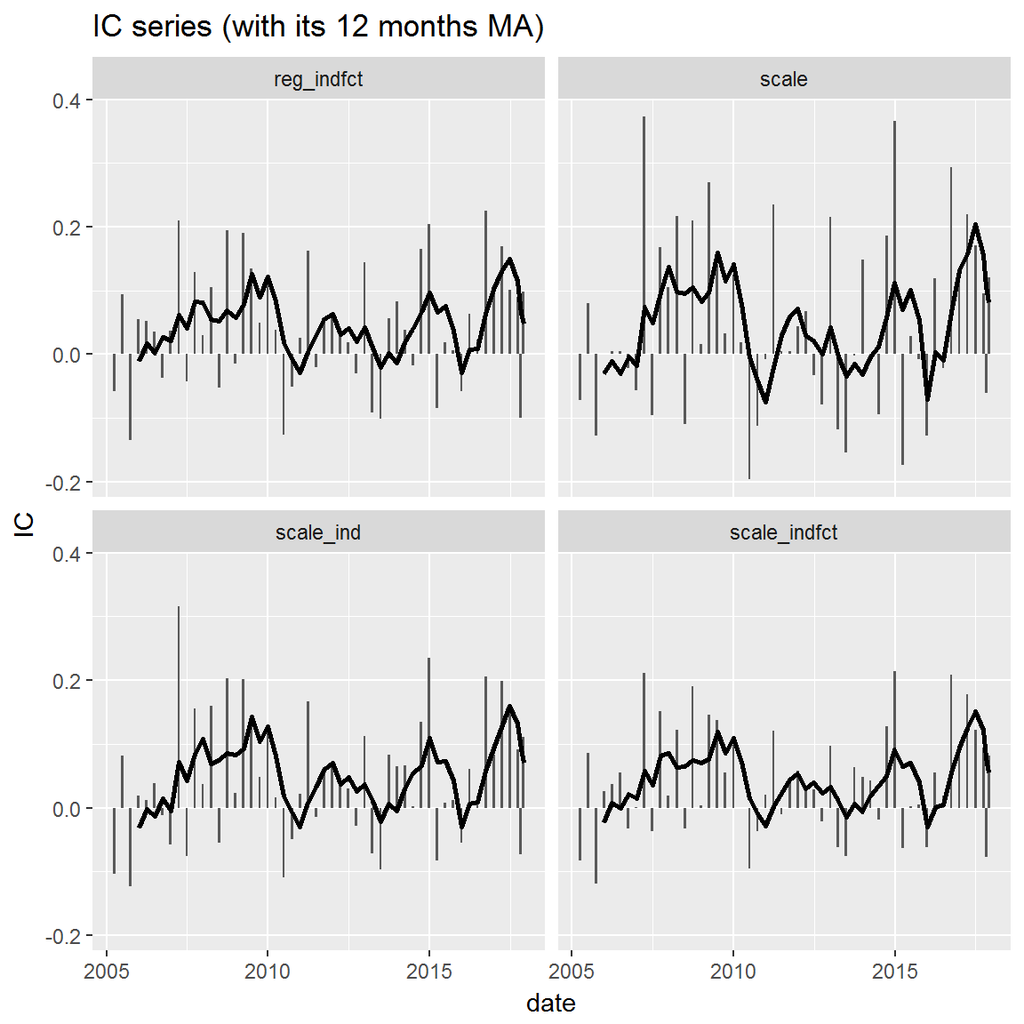

```r
MF.chart.IC(mTSFR = mtsfr,facet_by = 'fname')
```

不同refine方式下因子分组多空收益图

```
## The guessed factorNames are: scale,scale_ind,scale_indfct,reg_indfct.
```

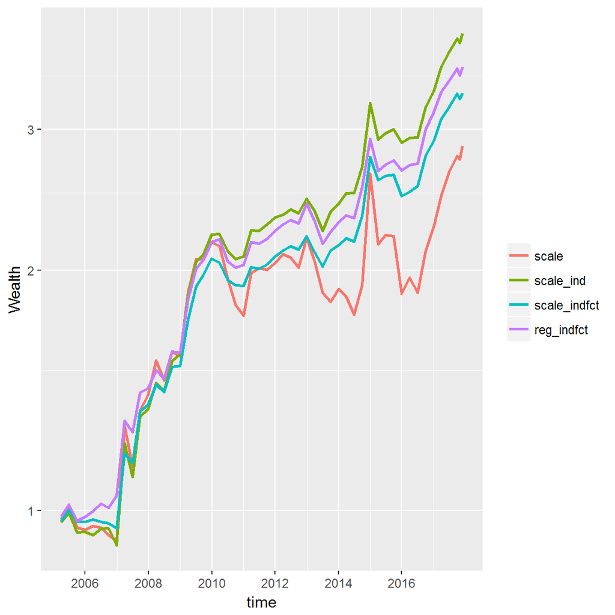

```r
MF.chart.Ngroup.spread(mTSFR = mtsfr, N = 5)
```

不同refine方式下因子分组多空相对收益图

```
## The guessed factorNames are: scale,scale_ind,scale_indfct,reg_indfct.
```

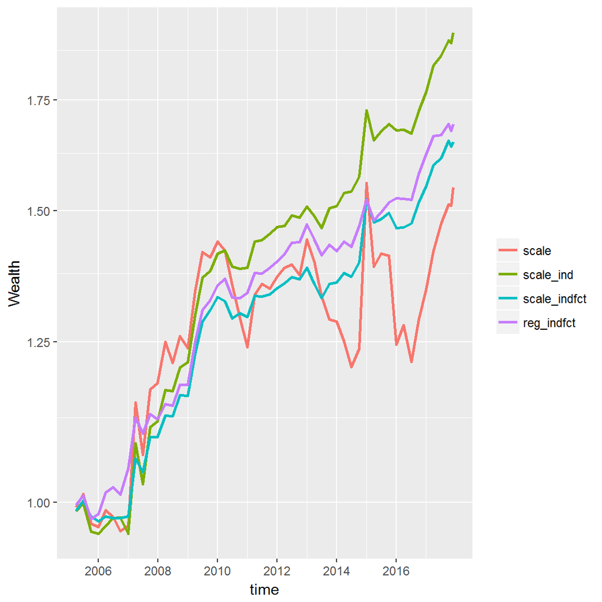

```r
MF.chart.Ngroup.spread(mTSFR = mtsfr, N = 5,rtn_type = "long-univ")
```

不同refine方式下因子IC和分组收益统计表

```r
table_ <- MC.table.ICandNgroup(mTSF2TSFs(mtsfr), N = 5)
```

```
## The guessed factorNames are: scale,scale_ind,scale_indfct,reg_indfct.
```

```r
kable(table_,digits = 2)
```

|  | IC_mean | IC_std | IC_IR | IC_t | IC_p | IC_hitRatio | IC_annu | Annualized Return | Annualized StdDev | Annualized Sharpe(Rf=0%) | HitRatio | Worst Drawdown | Annualized Turnover | Annualized Return (fee cut) | Beta | Size |
| --- | --- | --- | --- | --- | --- | --- | --- | --- | --- | --- | --- | --- | --- | --- | --- | --- |
| scale | 0.05 | 0.14 | 0.35 | 2.53 | 0.01 | 0.60 | 0.10 | 0.08 | 0.21 | 0.40 | 0.51 | 0.29 | 1.03 | 0.08 | 0.11 | 144.35 |
| scale_ind | 0.05 | 0.10 | 0.49 | 3.57 | 0.00 | 0.72 | 0.10 | 0.11 | 0.15 | 0.74 | 0.72 | 0.11 | 1.15 | 0.11 | 0.13 | 61.42 |
| scale_indfct | 0.04 | 0.08 | 0.51 | 3.69 | 0.00 | 0.70 | 0.09 | 0.10 | 0.12 | 0.82 | 0.64 | 0.11 | 1.28 | 0.10 | 0.10 | 61.43 |
| reg_indfct | 0.05 | 0.09 | 0.49 | 3.58 | 0.00 | 0.70 | 0.09 | 0.10 | 0.12 | 0.88 | 0.70 | 0.11 | 1.10 | 0.10 | 0.11 | 71.60 |

```r
table_ <- data.frame(factorName=fname_,refinePar=rownames(table_),table_,row.names = NULL,stringsAsFactors = FALSE)
tablestats <- rbind(tablestats,table_)
```

## PB三年期

```r
fname_ <- "capb"
tsfr <- tsfrs_raw[[fname_]]
mtsfr <- factor_refine_MF(tsfr,refinePars)
```

```
## Function getTSF: getting the factorscore ....
## Function getTSF: getting the factorscore ....
```

```r
mtsfrrefine <- rbind(mtsfrrefine,data.frame(mtsfr,fname=fname_))
```

不同refine方式下因子得分分布直方图

```
## The guessed factorNames are: scale,scale_ind,scale_indfct,reg_indfct.
```

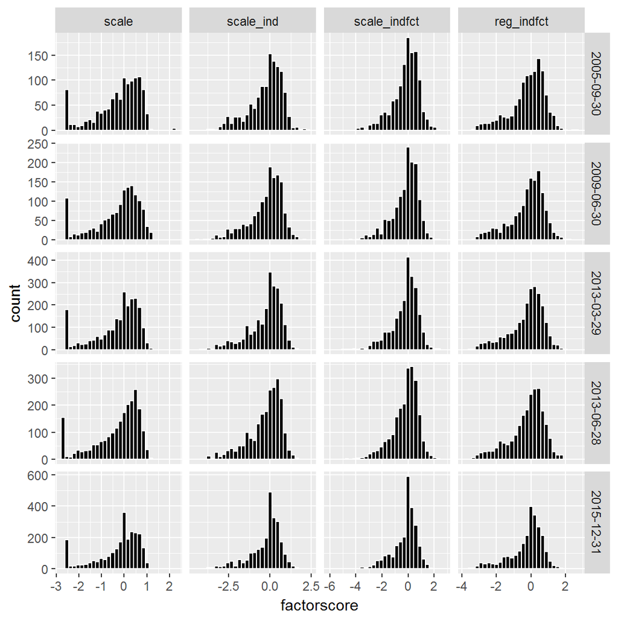

```r
MF.chart.Fct_hist(mtsfr,5)
```

不同refine方式下因子IC图

```
## The guessed factorNames are: scale,scale_ind,scale_indfct,reg_indfct.
```

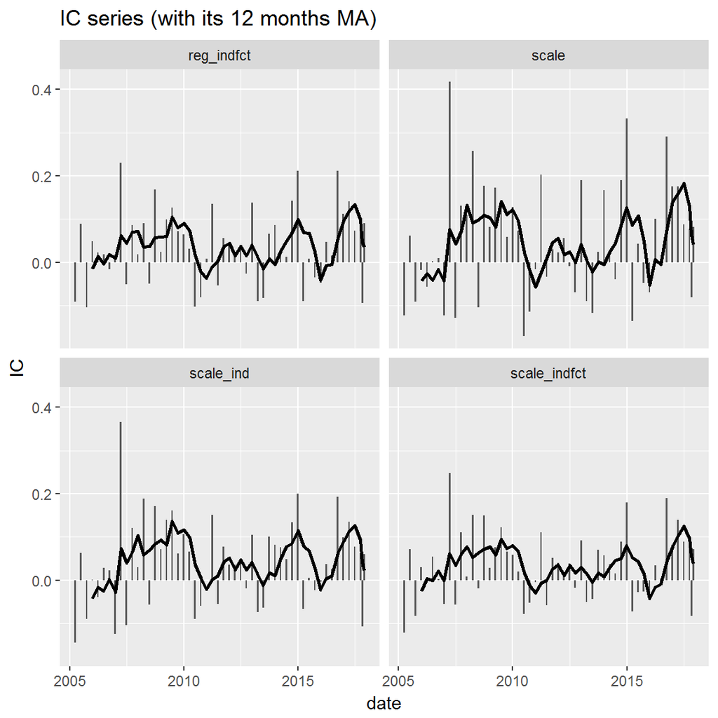

```r
MF.chart.IC(mTSFR = mtsfr,facet_by = 'fname')
```

不同refine方式下因子分组多空收益图

```
## The guessed factorNames are: scale,scale_ind,scale_indfct,reg_indfct.
```

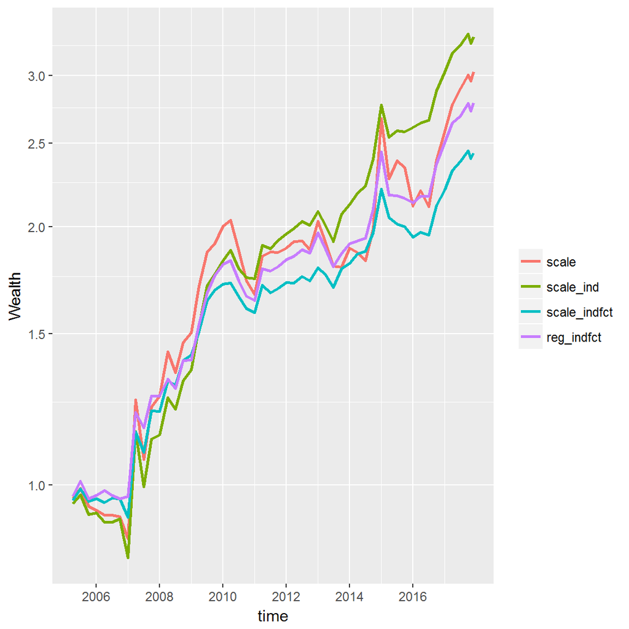

```r
MF.chart.Ngroup.spread(mTSFR = mtsfr, N = 5)
```

不同refine方式下因子分组多空相对收益图

```
## The guessed factorNames are: scale,scale_ind,scale_indfct,reg_indfct.
```

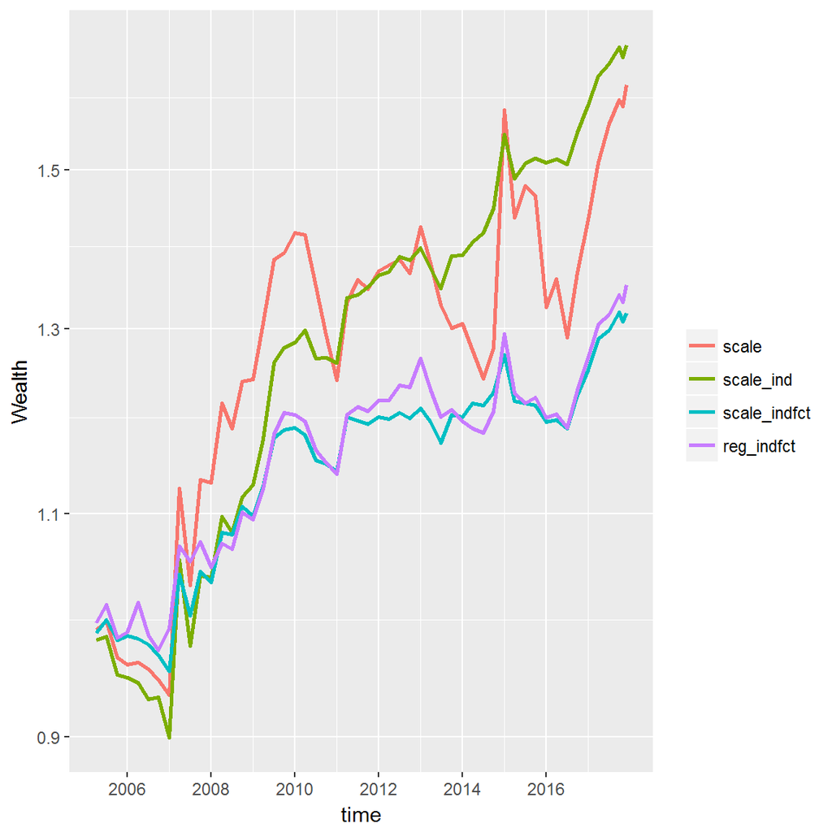

```r
MF.chart.Ngroup.spread(mTSFR = mtsfr, N = 5,rtn_type = "long-univ")
```

不同refine方式下因子IC和分组收益统计表

```r
table_ <- MC.table.ICandNgroup(mTSF2TSFs(mtsfr), N = 5)
```

```
## The guessed factorNames are: scale,scale_ind,scale_indfct,reg_indfct.
```

```r
kable(table_,digits = 2)
```

|  | IC_mean | IC_std | IC_IR | IC_t | IC_p | IC_hitRatio | IC_annu | Annualized Return | Annualized StdDev | Annualized Sharpe(Rf=0%) | HitRatio | Worst Drawdown | Annualized Turnover | Annualized Return (fee cut) | Beta | Size |
| --- | --- | --- | --- | --- | --- | --- | --- | --- | --- | --- | --- | --- | --- | --- | --- | --- |
| scale | 0.05 | 0.13 | 0.35 | 2.57 | 0.01 | 0.60 | 0.09 | 0.09 | 0.20 | 0.44 | 0.55 | 0.21 | 0.96 | 0.09 | 0.12 | 117.87 |
| scale_ind | 0.04 | 0.10 | 0.43 | 3.16 | 0.00 | 0.70 | 0.09 | 0.10 | 0.16 | 0.62 | 0.70 | 0.18 | 1.08 | 0.10 | 0.14 | 40.96 |
| scale_indfct | 0.03 | 0.08 | 0.43 | 3.11 | 0.00 | 0.66 | 0.07 | 0.07 | 0.11 | 0.66 | 0.58 | 0.12 | 1.22 | 0.07 | 0.08 | 55.99 |
| reg_indfct | 0.04 | 0.08 | 0.43 | 3.12 | 0.00 | 0.72 | 0.07 | 0.08 | 0.12 | 0.71 | 0.62 | 0.13 | 1.00 | 0.08 | 0.08 | 114.24 |

```r
table_ <- data.frame(factorName=fname_,refinePar=rownames(table_),table_,row.names = NULL,stringsAsFactors = FALSE)
tablestats <- rbind(tablestats,table_)
```

## PB三年期通胀调整

```r
fname_ <- "capb_adj"
tsfr <- tsfrs_raw[[fname_]]
mtsfr <- factor_refine_MF(tsfr,refinePars)
```

```
## Function getTSF: getting the factorscore ....
## Function getTSF: getting the factorscore ....
```

```r
mtsfrrefine <- rbind(mtsfrrefine,data.frame(mtsfr,fname=fname_))
```

不同refine方式下因子得分分布直方图

```
## The guessed factorNames are: scale,scale_ind,scale_indfct,reg_indfct.
```

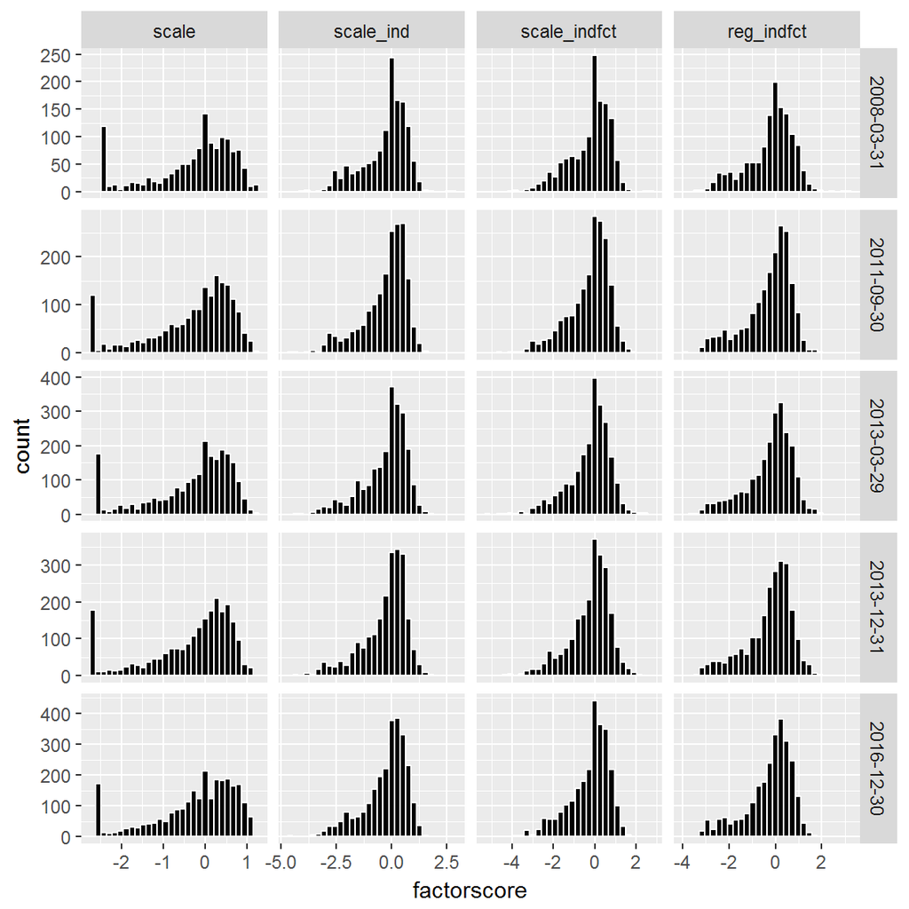

```r
MF.chart.Fct_hist(mtsfr,5)
```

不同refine方式下因子IC图

```
## The guessed factorNames are: scale,scale_ind,scale_indfct,reg_indfct.
```

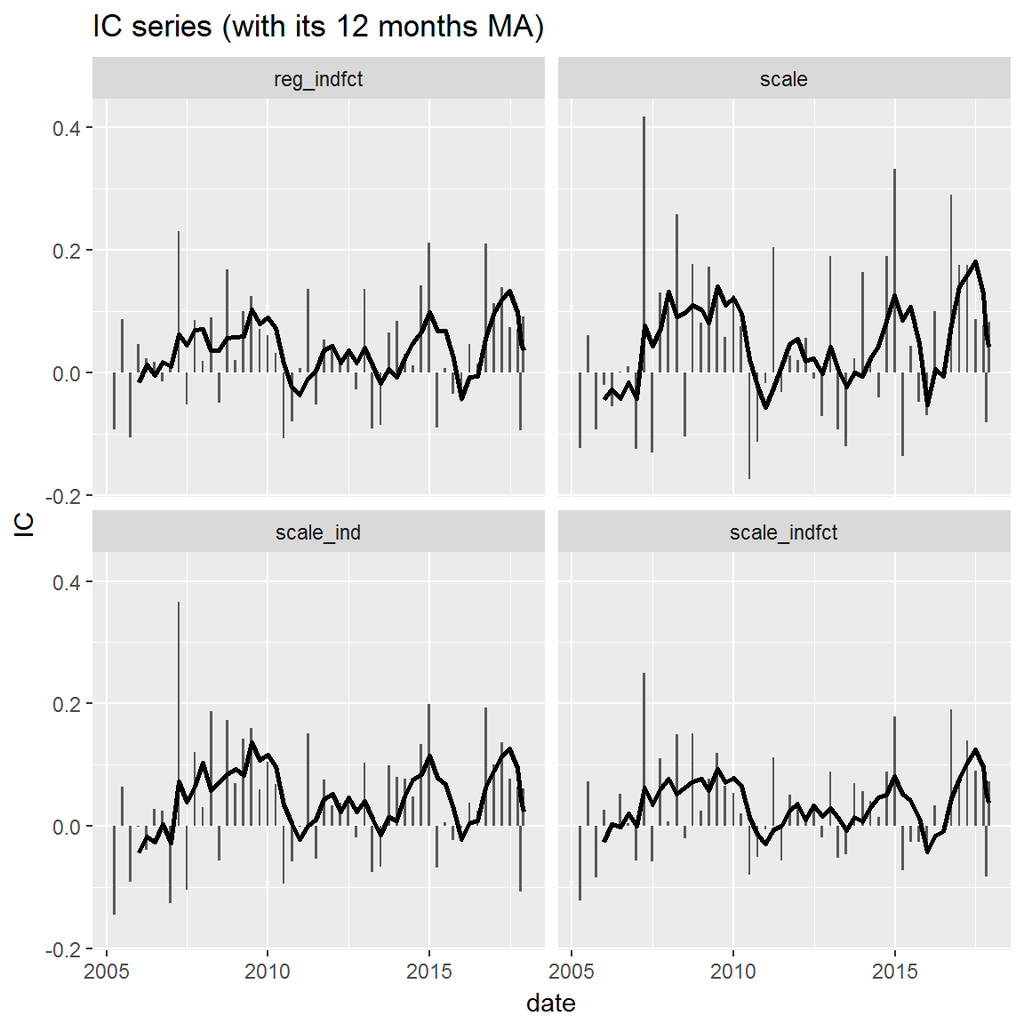

```r
MF.chart.IC(mTSFR = mtsfr,facet_by = 'fname')
```

不同refine方式下因子分组多空收益图

```
## The guessed factorNames are: scale,scale_ind,scale_indfct,reg_indfct.
```

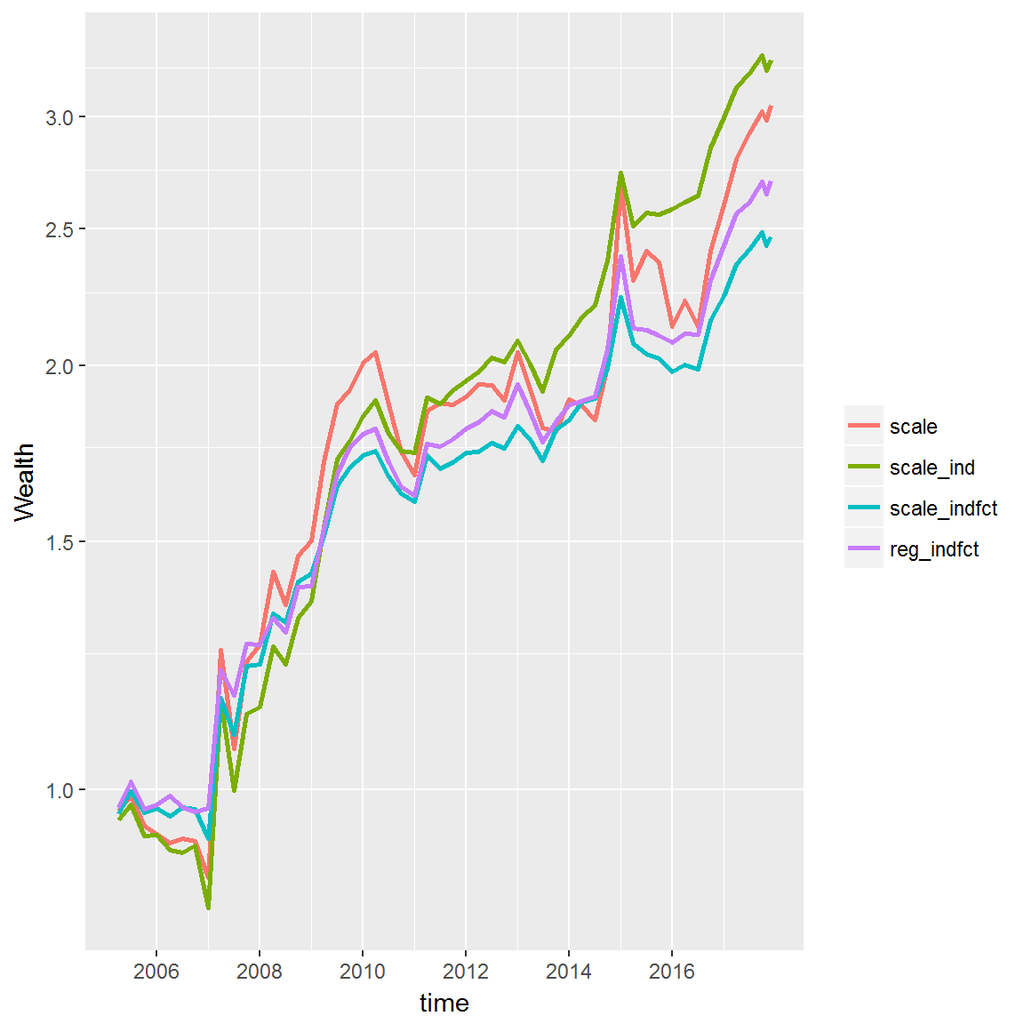

```r
MF.chart.Ngroup.spread(mTSFR = mtsfr, N = 5)
```

不同refine方式下因子分组多空相对收益图

```
## The guessed factorNames are: scale,scale_ind,scale_indfct,reg_indfct.
```

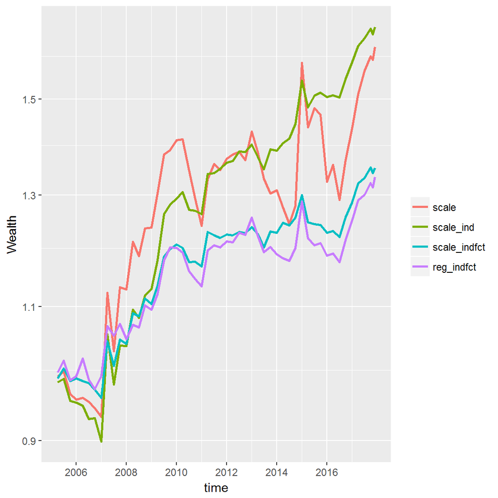

```r
MF.chart.Ngroup.spread(mTSFR = mtsfr, N = 5,rtn_type = "long-univ")
```

不同refine方式下因子IC和分组收益统计表

```r
table_ <- MC.table.ICandNgroup(mTSF2TSFs(mtsfr), N = 5)
```

```
## The guessed factorNames are: scale,scale_ind,scale_indfct,reg_indfct.
```

```r
kable(table_,digits = 2)
```

|  | IC_mean | IC_std | IC_IR | IC_t | IC_p | IC_hitRatio | IC_annu | Annualized Return | Annualized StdDev | Annualized Sharpe(Rf=0%) | HitRatio | Worst Drawdown | Annualized Turnover | Annualized Return (fee cut) | Beta | Size |
| --- | --- | --- | --- | --- | --- | --- | --- | --- | --- | --- | --- | --- | --- | --- | --- | --- |
| scale | 0.05 | 0.13 | 0.35 | 2.55 | 0.01 | 0.60 | 0.09 | 0.09 | 0.20 | 0.45 | 0.55 | 0.21 | 0.97 | 0.09 | 0.13 | 117.53 |
| scale_ind | 0.04 | 0.10 | 0.43 | 3.14 | 0.00 | 0.66 | 0.09 | 0.10 | 0.16 | 0.62 | 0.68 | 0.18 | 1.08 | 0.10 | 0.14 | 38.38 |
| scale_indfct | 0.03 | 0.08 | 0.42 | 3.08 | 0.00 | 0.66 | 0.07 | 0.07 | 0.11 | 0.66 | 0.62 | 0.11 | 1.22 | 0.07 | 0.08 | 54.34 |
| reg_indfct | 0.04 | 0.09 | 0.42 | 3.08 | 0.00 | 0.72 | 0.07 | 0.08 | 0.12 | 0.68 | 0.62 | 0.13 | 1.00 | 0.08 | 0.08 | 115.47 |

```r
table_ <- data.frame(factorName=fname_,refinePar=rownames(table_),table_,row.names = NULL,stringsAsFactors = FALSE)
tablestats <- rbind(tablestats,table_)
```

## PCF_ttm

```r
fname_ <- "pcf_ttm"
tsfr <- tsfrs_raw[[fname_]]
mtsfr <- factor_refine_MF(tsfr,refinePars)
```

```
## Function getTSF: getting the factorscore ....
## Function getTSF: getting the factorscore ....
```

```r
mtsfrrefine <- rbind(mtsfrrefine,data.frame(mtsfr,fname=fname_))
```

不同refine方式下因子得分分布直方图

```
## The guessed factorNames are: scale,scale_ind,scale_indfct,reg_indfct.
```

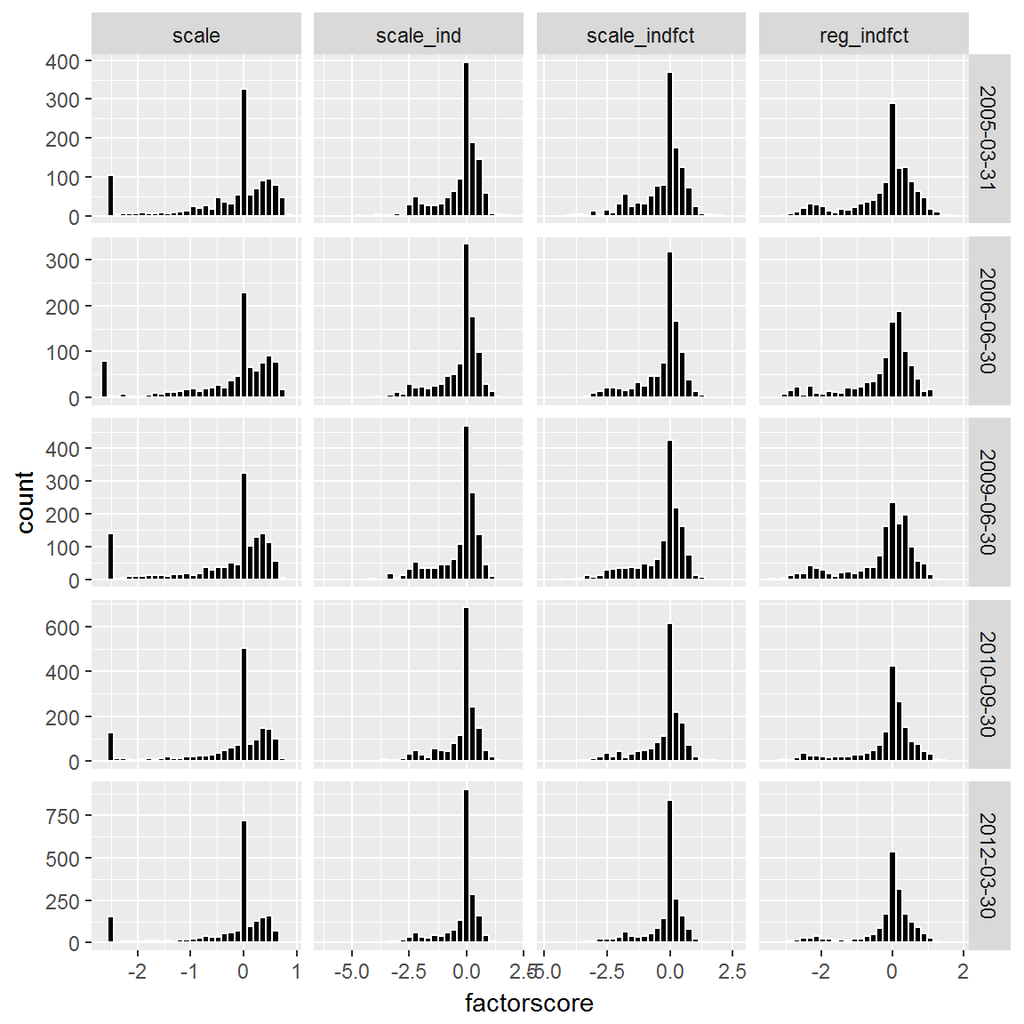

```r
MF.chart.Fct_hist(mtsfr,5)
```

不同refine方式下因子IC图

```
## The guessed factorNames are: scale,scale_ind,scale_indfct,reg_indfct.
```

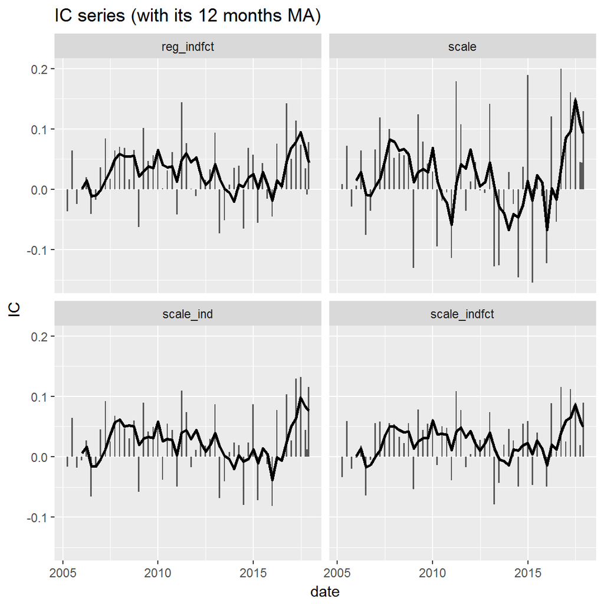

```r
MF.chart.IC(mTSFR = mtsfr,facet_by = 'fname')
```

不同refine方式下因子分组多空收益图

```
## The guessed factorNames are: scale,scale_ind,scale_indfct,reg_indfct.
```

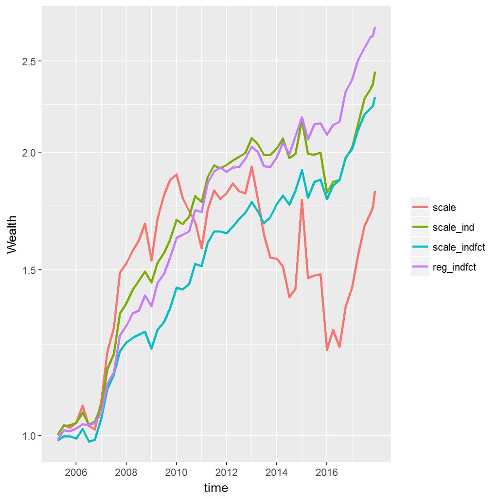

```r
MF.chart.Ngroup.spread(mTSFR = mtsfr, N = 5)
```

不同refine方式下因子分组多空相对收益图

```
## The guessed factorNames are: scale,scale_ind,scale_indfct,reg_indfct.
```

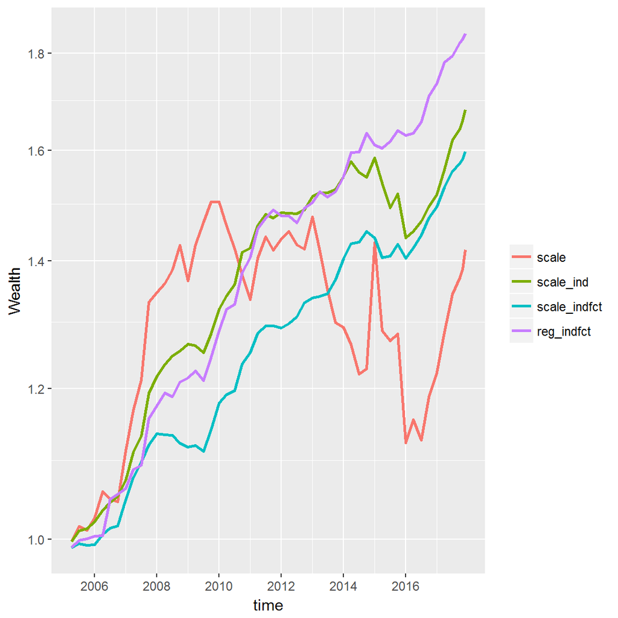

```r
MF.chart.Ngroup.spread(mTSFR = mtsfr, N = 5,rtn_type = "long-univ")
```

不同refine方式下因子IC和分组收益统计表

```r
table_ <- MC.table.ICandNgroup(mTSF2TSFs(mtsfr), N = 5)
```

```
## The guessed factorNames are: scale,scale_ind,scale_indfct,reg_indfct.
```

```r
kable(table_,digits = 2)
```

|  | IC_mean | IC_std | IC_IR | IC_t | IC_p | IC_hitRatio | IC_annu | Annualized Return | Annualized StdDev | Annualized Sharpe(Rf=0%) | HitRatio | Worst Drawdown | Annualized Turnover | Annualized Return (fee cut) | Beta | Size |
| --- | --- | --- | --- | --- | --- | --- | --- | --- | --- | --- | --- | --- | --- | --- | --- | --- |
| scale | 0.02 | 0.09 | 0.28 | 2.01 | 0.05 | 0.62 | 0.05 | 0.05 | 0.15 | 0.33 | 0.62 | 0.36 | 1.54 | 0.05 | 0.00 | 246.04 |
| scale_ind | 0.03 | 0.05 | 0.47 | 3.44 | 0.00 | 0.70 | 0.05 | 0.07 | 0.07 | 0.97 | 0.77 | 0.16 | 1.79 | 0.07 | 0.01 | 54.18 |
| scale_indfct | 0.03 | 0.05 | 0.56 | 4.06 | 0.00 | 0.72 | 0.05 | 0.07 | 0.06 | 1.13 | 0.77 | 0.07 | 1.93 | 0.07 | 0.02 | 32.42 |
| reg_indfct | 0.03 | 0.05 | 0.55 | 4.02 | 0.00 | 0.72 | 0.06 | 0.08 | 0.06 | 1.35 | 0.77 | 0.05 | 1.82 | 0.08 | 0.03 | -42.32 |

```r
table_ <- data.frame(factorName=fname_,refinePar=rownames(table_),table_,row.names = NULL,stringsAsFactors = FALSE)
tablestats <- rbind(tablestats,table_)
```

## PCF三年期

```r
fname_ <- "capcf"
tsfr <- tsfrs_raw[[fname_]]
mtsfr <- factor_refine_MF(tsfr,refinePars)
```

```
## Function getTSF: getting the factorscore ....
## Function getTSF: getting the factorscore ....
```

```r
mtsfrrefine <- rbind(mtsfrrefine,data.frame(mtsfr,fname=fname_))
```

不同refine方式下因子得分分布直方图

```
## The guessed factorNames are: scale,scale_ind,scale_indfct,reg_indfct.
```

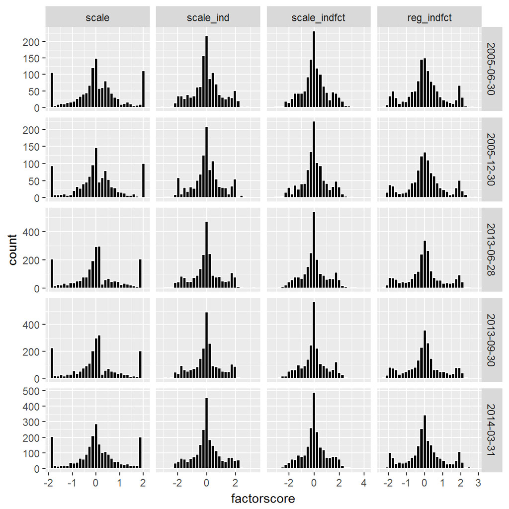

```r
MF.chart.Fct_hist(mtsfr,5)
```

不同refine方式下因子IC图

```
## The guessed factorNames are: scale,scale_ind,scale_indfct,reg_indfct.
```

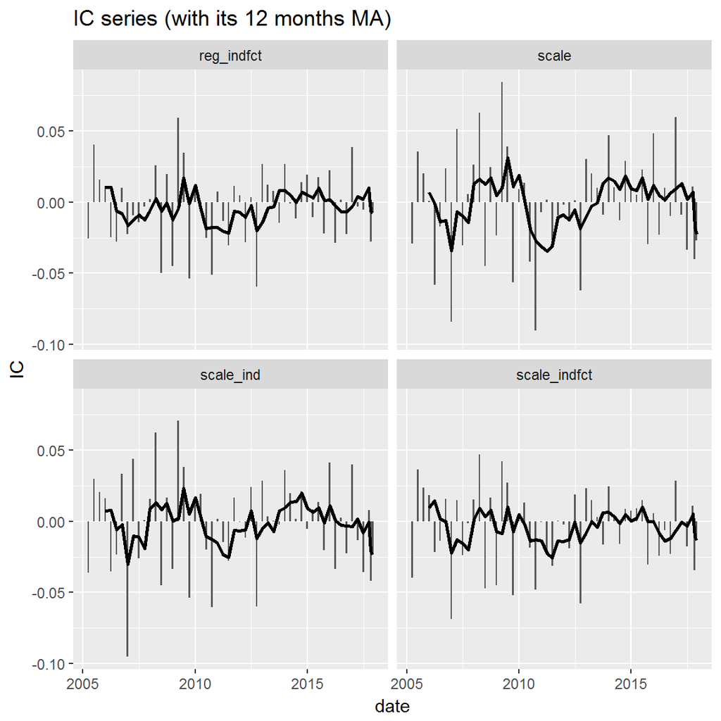

```r
MF.chart.IC(mTSFR = mtsfr,facet_by = 'fname')
```

不同refine方式下因子分组多空收益图

```
## The guessed factorNames are: scale,scale_ind,scale_indfct,reg_indfct.
```

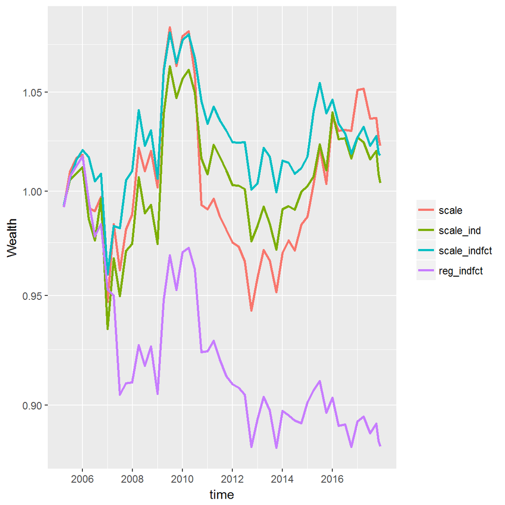

```r
MF.chart.Ngroup.spread(mTSFR = mtsfr, N = 5)
```

不同refine方式下因子分组多空相对收益图

```
## The guessed factorNames are: scale,scale_ind,scale_indfct,reg_indfct.
```

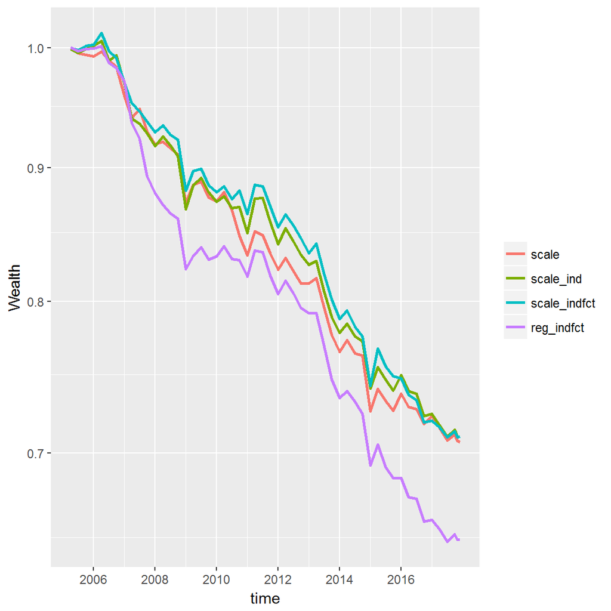

```r
MF.chart.Ngroup.spread(mTSFR = mtsfr, N = 5,rtn_type = "long-univ")
```

不同refine方式下因子IC和分组收益统计表

```r
table_ <- MC.table.ICandNgroup(mTSF2TSFs(mtsfr), N = 5)
```

```
## The guessed factorNames are: scale,scale_ind,scale_indfct,reg_indfct.
```

```r
kable(table_,digits = 2)
```

|  | IC_mean | IC_std | IC_IR | IC_t | IC_p | IC_hitRatio | IC_annu | Annualized Return | Annualized StdDev | Annualized Sharpe(Rf=0%) | HitRatio | Worst Drawdown | Annualized Turnover | Annualized Return (fee cut) | Beta | Size |
| --- | --- | --- | --- | --- | --- | --- | --- | --- | --- | --- | --- | --- | --- | --- | --- | --- |
| scale | 0 | 0.04 | -0.04 | -0.28 | 0.78 | 0.53 | 0.00 | 0.00 | 0.04 | 0.04 | 0.51 | 0.13 | 1.08 | 0.00 | 0.04 | -12.32 |
| scale_ind | 0 | 0.03 | -0.05 | -0.40 | 0.69 | 0.55 | 0.00 | 0.00 | 0.04 | 0.01 | 0.49 | 0.09 | 1.13 | 0.00 | 0.04 | -29.51 |
| scale_indfct | 0 | 0.03 | -0.18 | -1.29 | 0.20 | 0.49 | -0.01 | 0.00 | 0.03 | 0.04 | 0.49 | 0.08 | 1.19 | 0.00 | 0.03 | -21.51 |
| reg_indfct | 0 | 0.03 | -0.14 | -1.02 | 0.31 | 0.47 | -0.01 | -0.01 | 0.03 | -0.30 | 0.47 | 0.13 | 1.13 | -0.01 | 0.01 | 10.86 |

```r
table_ <- data.frame(factorName=fname_,refinePar=rownames(table_),table_,row.names = NULL,stringsAsFactors = FALSE)
tablestats <- rbind(tablestats,table_)
```